# Lab 4

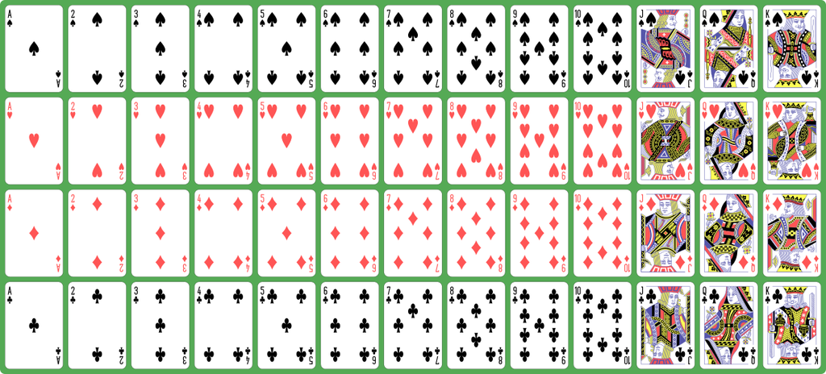

In this lab we build a data.frame to represent a standard deck of 52 playing cards.  
It should have 52 rows and one column for each characteristic of a playing card:

- color $\in$ `{"black", "red"}`
- suit $\in$ `{"clubs", "spades", "diamonds", "hearts" }`
- name $\in$ `{"ace", "2", "3", ..., "king"}`
- rank $\in$ `{1,2,3, ..., 12,13}`
- value $\in$ `{1,2,3, ..., 9,10,10,10,10 }`.

For more information or clarity, see here: https://en.wikipedia.org/wiki/Standard_52-card_deck

#### Building deck52

1. (10 points) Clean. Stylish.
2. Build the vector **color** first. It should have 52 elements. Build it like this: **color** = [“red” 13 times, “black” 13 times, “red” 13 times, “black” 13 times] . Useful commands are `c()` and `rep()`.
3. Build a vector with 52 elements for each of the other four columns: **suit, name, rank, value**.
4. (20 points) Use `data.frame()` to combine the columns into a single data.frame called `deck52`. Confirm that your data.frame has 52 rows and 5 columns. Make sure it represents an actual deck of cards; check the image to be sure. Run `names(deck52) <- toupper(names(deck52))` to convert the column names to upper case.

#### Extracting events

Consider selecting a card at random from a standard deck. The sample space $\Omega$ can be represented by `deck52`. Each row of `deck52` represents a possible outcome and has probability = 1/52. An event is any subset of $\Omega$, so any event corresponds to a set of rows in `deck52`. Below we define some examples of events associated with this experiment.

Let $B$ = the event that the selected card is black.

Let $R$ = the event that the selected card is red.

Let $D$ = the event that SUIT of the selected card is diamonds, and let $H, S, C$ define the same event for the other three suits.

Let $FACE$ = the event that card is a face card = {jack, queen, king}.

Let $A$ = the event that the card is an ace.

Let $ODD$ = the event that the VALUE of the card is odd.

Let $LOW$ = the event that the RANK of the card is less than 3.

5. (10 points) For each event above, extract and display the corresponding rows of `deck52`. Use `subset` or use the `filter` function from the package `dplyr` (loaded above). Here’s the first one:

```r
B <- filter(deck52, COLOR == 'black') # extracting the event B
B                                     # displaying the subsetted dataframe B
```

*Hints:*

- Type `help(Logic)` or `help("\&")` to see help page for `&` and other logical operators.
- Type `help(Comparison)` or `help("==")` for $<$, $>$ and other comparison operators.
- Type `help(Arithmetic)` or `help("+")` for arithmetic operators like + and $*$. We need `%%` for this assignment.  
  Note the difference between `%%` and $\%/\%$.

#### Computing probabilities

Calculate the probabilities below using R. The first one is an example.

6. $P(H) =$ __________ . It helps to work it out with a pencil first: $P(H) = \frac{13 \ hearts}{52 \ cards} = \frac{1}{4}$. How do we get 13/52 in R? To get the 13 use `dim(H)[1]` or `nrow(H)`. To get the 52 use `dim(deck52)[1]` or `nrow(deck52)`. Then divide 13/52 to get the answer, 0.25.

```r
H <- filter(deck52, SUIT == 'hearts') # extracting the event H, part of previous question
p_H <- nrow(H) / nrow(deck52)
p_H # display the answer
```

7. $P(FACE)$
8. $P(ODD)$
9. $P(EVEN)$. This is one minus previous answer, but don’t solve it that way. Extract the rows where value is even, count them, and divide by 52.
10. $P(ODD^C)$. Same as previous problem, but solve it explicitly: extract the rows that are NOT odd, count, divide.
11. $P(D)$.
12. $P(D \cap R)$. Intersection means AND which is $\&$ in R.
13. $P(D | R)$.
14. $P(D \cup R)$. Union means OR which is $|$ in R. Note that this is unrelated to the $|$ used in conditional probability.
15. $P(F | EVEN)$.
16. (30 points) Package your probability answers in a 10x3 data.frame called `myprobs`. Run `myprobs <- data.frame(question = '6', probability = 'P(H)', answer = p_H)` to see the first row as an example. Attach new rows with `rbind()`. When the data.frame is complete, run `myprobs` to display it. Don’t use `View()`.

#### Two more things

17. (15 points) Build `deck52` again. This time start with **color** = [“black”, “red”, “black”, “red”, etc. ].
18. (15 points) Mötorhead meets Juice Newton A level: Make a new column called **LONGNAME** with entries like “3 of diamonds”, “jack of clubs”, etc. Add this column to `deck52`. For full credit build **LONGNAME** with a single function call.